[figure not shown]

[figure not shown]

Review

[figure not shown]

Early-phase dose articulation trials are underutilized for post-stroke

motor recovery: A systematic scoping review

Emily J. Dalton <sup>a</sup>, Leonid Churilov <sup>b</sup>, Natasha A. Lannin <sup>c</sup><sup>,</sup><sup>d</sup>, Dale Corbett <sup>e</sup>,

Bruce C.V. Campbell <sup>f</sup>, Kathryn S. Hayward <sup>g</sup><sup>,</sup>*

a Melbourne School of Health Sciences, University of Melbourne, Heidelberg, Australia

b Melbourne Medical School, University of Melbourne, Parkville, Australia

c Department of Neurosciences, Central Clinical School, Monash University, Melbourne, Australia

d Alfred Health, Melbourne, Australia

e Cellular & Molecular Medicine and Canadian Partnership for Stroke Recovery, University of Ottawa, Canada

f Department of Medicine and Neurology, Melbourne Brain Centre, Royal Melbourne Hospital, University of Melbourne, Parkville, Australia

g Melbourne School of Health Sciences and Florey Institute of Neuroscience and Mental Health, University of Melbourne, 245 Burgundy Street,

3084 Heidelberg, Australia

1. Introduction

The

volume

of

stroke

recovery

research

has

increased

exponentially over recent decades, with a noticeable shift toward

later-phase clinical trials. Appropriate application of Phase III trials

can determine the therapeutic efﬁcacy of an intervention through

adequately powered studies [1]. To achieve this, interventions

should ﬁrst investigate the biological basis for recovery, safety, and

feasibility with a systematic phased approach [1].

Behavioral motor interventions for stroke recovery are com-

plex, with multiple inter-related components that collectively aim

to address a speciﬁc post-stroke impairment [2]. A rationale

(theoretical and biological) to justify the selection of components is

required to have conﬁdence in trial results. Previous stroke

recovery trials have often evaluated relatively low doses of therapy

(� 30 min/day) [3] and/or recruited participants at late post-stroke

stage (> 6 months)[4]. Determining whether the therapy was

ineffective in terms of how much, when or what was delivered is

A R T I C L E

I N F O

Article history:

Received 5 June 2020

Accepted 30 November 2020

Keywords:

Stroke rehabilitation

Clinical trial

Translational medical research

Animal model

Neuroscience

Dosing

A B S T R A C T

Background: To enable development of effective interventions, there is a need to complete systematic

early-phase dose articulation research. This scoping review aimed to synthesize dose articulation

research of behavioral motor interventions for stroke recovery.

Methods: MEDLINE and EMBASE were systematically searched for dose articulation studies. Preclinical

experiments and adult clinical trials were classiﬁed based on the discovery pipeline and analyzed to

determine which dose dimensions were articulated (time, scheduling or intensity) and how they were

investigated (unidimensional vs multidimensional approach). Reporting of dose, safety and efﬁcacy

outcomes were summarized. The intervention description, risk of bias, and quality was appraised.

Results: We included 41 studies: 3 of preclinical dose preparation (93 rodents), 2 Phase I dose ranging

(21 participants), 9 Phase IIA dose screening (198 participants), and 27 Phase IIB dose ﬁnding

(1879 participants). All studies adopted a unidimensional approach. Time was the most frequent

dimension investigated (53%), followed by intensity (29%), and scheduling (18%). Overall, 95% studies

reported an efﬁcacy outcome; however, only 65% reported dose and 45% reported safety. Across studies,

61% were at high risk of bias, and the average percentage reporting of intervention description and

quality was 61% and 67%, respectively.

Conclusion: This review highlights a need to undertake more high-quality, early-phase studies that

systematically articulate intervention doses from a multidimensional perspective in the ﬁeld of

behavioral motor stroke recovery. To address this gap, we need to invest in adapting early phase trial

designs, especially Phase I, to support multidimensional dose articulation.

�

C 2021 Elsevier Masson SAS. All rights reserved.

* Corresponding author.

E-mail address: kate.hayward@unimelb.edu.au (K.S. Hayward).

ScienceDirect

www.sciencedirect.com

https://doi.org/10.1016/j.rehab.2021.101487

1877-0657/<sup>�</sup>

C 2021 Elsevier Masson SAS. All rights reserved.

difﬁcult. Dose (how much) is considered a key component to

systematically investigate prior to intervention testing in later-

phase trials, but optimizing dose for the best recovery continues to

be a challenge [3]. Lack of consideration for the complexity of dose

is a potential reason for neutral Phase III trial results [3]. A

framework for complex intervention development exists, detailing

a broad process of development, feasibility, implementation and

evaluation [5]. This framework informs researchers about what to

do but not how to go about it. In particular, it does not outline a

systematic approach to investigate the individual components,

such as dose, within the development stage. To address this gap,

we previously deﬁned a systematic discovery pipeline approach

[6] based on the principles and clinical trial phases in the US Food

and Drug Administration (FDA) [1] guidelines for clinical research.

This pipeline serves to address an international consensus

recommendation [3] that deﬁned the need to systematically

investigate dose.

To apply this pipeline approach, a clear deﬁnition of dose is

necessary. In pharmaceutical interventions, dose refers to the

amount of drug delivered to elicit a physiological response and

may vary in terms of scheduling or intensity. For non-pharmaco-

logical interventions, the identiﬁcation and operationalization of

dose is more challenging. In the context of behavioral motor

interventions, the challenges stem from the increased complexity

of interventions, with dose dimensions often poorly quantiﬁed or

controlled within the study design [7]. Preclinical experiments

have tended to consider dose in terms of repetitions (e.g., number

of reaches) [3]. Largely for pragmatic reasons, clinical trials usually

focus on time in therapy environment [8]. For this review, we used

the most common deﬁnitions reported in the literature that

capture recognized dose dimensions of behavioral motor inter-

ventions [9]. These include the following:

� dose dimensions, including:

� time: time on task and time in therapy environment,

� scheduling: number of sessions/day, number of days/week,

intervention duration, and

� intensity: level of task difﬁculty, e.g., repetitions/minute,

rating of perceived exertion or amount of rest period;

� dose articulation studies aim to investigate dose by manipulat-

ing one or more dose dimensions while keeping others ﬁxed;

� discovery pipeline [6] demonstrates a systematic phased

approach that links preclinical and clinical dose articulation

studies within their appropriate phases.

A clear understanding of the multiple dose dimensions and a

systematic approach to guide their investigation is key to align

stroke recovery research with international consensus recom-

mendations [3]. A lack of early phase research that systematically

articulates the multiple dose dimensions can result in expensive

Phase III trials that do not have a clear justiﬁcation for dose.

Skipping steps in the development of complex, behavioral motor

interventions is a barrier to advancing stroke recovery research.

Therefore, we must ﬁrst understand how much early-phase dose

articulation research has been completed in the context of

behavioral motor interventions for stroke recovery.

2. Identifying the research question

The objective of this scoping review was to address what is

known about dose articulation in preclinical and clinical stroke

recovery, focusing on behavioral motor interventions. Our aims

were to synthesize the literature on dose articulation in preclinical

and clinical research, and discuss how well dose articulation designs

adopted by individual studies address their stated research aim.

2.1. Methods

We followed an established 5-stage methodological framework

[10,11]: identifying the research question, identifying relevant

studies, study selection, charting the data, and collating, summa-

rizing and reporting the results. This review was reported

according to the Preferred Reporting Items for Systematic Reviews

and Meta Analyses scoping review (PRISMA-ScR) guidelines [12]

and adheres to the prespeciﬁed protocol [6].

2.2. Identifying relevant studies

MEDLINE and EMBASE were systematically searched for articles

published in English up to August 6, 2020 (strategy in Supplement

File 1, Appendix A). Reference lists of relevant studies including

systematic

reviews

were

hand-searched.

For

scientiﬁc

and

pragmatic reasons, the preclinical search was restricted to

upper-limb behavioral motor interventions (reaching/retrieval;

see Supplement File 1, Appendix A, for rationale). Terms for the

preclinical search included words related to stroke, recovery,

reaching, and animals and for the clinical search included stroke,

recovery, dose, and early phase designs.

2.3. Study selection

Included studies had an explicit aim to articulate dose of a

behavioral motor intervention during any phase of stroke recovery

[3,13] (eligibility criteria in Supplement File 1, Appendix A). These

studies ranged from preclinical experiments to Phase IIB clinical

trials as per systematic discovery pipeline [6]. Studies of drug

intervention, non-invasive brain stimulation, systematic reviews

and conference abstracts were excluded. Search results were

managed in Covidence. Given the large volume of articles, one

author (ED) screened title/abstracts with a low tolerance to take

articles through to full-text screening. Two authors screened full-

text articles (ED/DC preclinical; ED/KH clinical). Discrepancies

were ﬁrst discussed to achieve consensus and otherwise with a

third reviewer (LC).

2.4. Charting the data

We implemented separate data charting forms for preclinical

experiments and clinical trials. Two members (ED/LC) of the

research team classiﬁed included studies to the most appropriate

discovery pipeline phase based on their stated aim [6]. Data were

extracted for study information, population information, dose

dimensions, study outcomes, intervention description, risk of bias,

and quality.

Study information included aim, design, type of intervention

(upper limb, lower limb, exercise or function deﬁned in Supple-

ment File 2, Appendix B), dose deﬁnition, and outcome timepoints.

Data extracted on population information included sample size,

sex, age, and phase of recovery per consensus guidelines [3,13]. For

reference, the recovery phases for rodents were hyperacute 0–24 h,

acute 1 to 5 days, early subacute 5 days to 4 weeks, late subacute

30 to 60 days, or chronic > 60 days, and for non-human primates

hyperacute 0 to 24 h, acute 1 to 7 days, early subacute 7 days to

6 weeks, late subacute 6 weeks to 3 months or chronic > 3 months

[3]. The clinical recovery phases were deﬁned as hyperacute 0 to

24 hr, acute 1 to 7 days, early subacute 7 days to 3 months, late

subacute 3 to 6 months or chronic > 6 months [13].

Dose, safety, and efﬁcacy outcomes were extracted. Consistent

with the aims of early-phase dose articulation research, all studies

(preclinical to Phase IIB) should report at least dose and safety

outcomes. Dose outcomes included reporting one or more of the

dose dimensions of time, intensity and schedule (as reported

above). We classiﬁed adverse events, including pain, fatigue or

withdrawals due to prescribed dose, as safety outcomes. Interven-

tion and dose efﬁcacy outcomes were drawn from clinical

measures (e.g., Fugl Meyer Assessment) used to determine the

effect of the intervention or dose of intervention provided.

Preclinical intervention descriptions were evaluated by using

Animal Research: Reporting of in vivo Experiments (ARRIVE), and

the

Template

for

Intervention

Description

and

Replication

checklist (TIDieR) was used to evaluate clinical trials. Preclinical

risk of bias was rated by using Systematic Review Centre for

Laboratory Animal Experimentations (SYRCLE). For clinical trials,

the Cochrane Risk of Bias tool 2 (Cochrane RoB2) was used for all

randomized controlled trials and the Risk of Bias in Non-

Randomized Studies of Interventions (ROBINS-I) for all other

designs. The Early Phase Research Quality Checklist (EPRQC) [6]

was used to rate the quality of all included studies according to

their discovery pipeline phase. The EPRQC was also used to

determine whether the stated dose articulation aim was appro-

priately investigated within an experiment or trial. References for

preclinical and clinical rating tools are reported in Supplement File

1, Appendix A).

One author (ED) critically appraised the included experiments

and trials with these tools, and a second author (DC preclinical, KH

clinical, LC quality) reviewed a random sample (� 15%) for

reliability.

2.5. Collating, summarizing and reporting the results

Results were tabulated according to the discovery pipeline

[6]. Data were analyzed to determine what dose dimensions were

articulated (time, scheduling or intensity) and how they were

investigated (unidimensional vs multidimensional). Reporting of

dose, safety and efﬁcacy outcomes was documented as present or

absent. In addition to preclinical dose preparation, we applied the

conventional trial phases as outlined in the discovery pipeline [6]:

Phase I dose ranging, Phase IIA dose screening, Phase IIB dose

ﬁnding (response), and Phase IIB dose ﬁnding (optimal) to

determine the appropriate intervention description and risk of

bias and quality tool [6]. The process for rating is outlined in

Supplement File 1 (Appendix A).

3. Results

We included 42 studies after full text review (Fig. 1). There was

one repeat sample [14], which was a secondary analysis of a Phase

IIB clinical trial [4]. Therefore, 41 independent study samples

All preclinical experiments focused on the upper limb as

directed by the search strategy. Most clinical trials aimed to

investigate the dose of an upper-limb intervention (60%), followed

by the lower limb (21%), exercise (11%), and general function (8%)

(results table in Supplement File 2, Appendix B). Intervention was

most common in the early subacute or chronic phase of stroke

recovery

[13]

(49%

and

37%

respectively;

results

table

in

Supplement File 2, Appendix B). Despite all studies aiming to

investigate the dose of a behavioral motor intervention, a

deﬁnition of dose was provided in only 24% of included studies.

Common phrases used within the studies included ‘‘dose response

relationship’’, ‘‘high dose/intensity’’, ‘‘low dose/intensity’’, and

‘‘dose

effect’’.

However,

the

deﬁnitions

reported

were

not

consistent (e.g., dose was considered to include ‘‘frequency,

intensity, time, and type’’[15] as parameters in one trial but

deﬁned as a ‘‘duration based measure’’[16] in another trial). All

studies investigated dose from a unidimensional perspective,

either screening a dose regimen of ﬁxed dimensions or manipu-

lating one dose dimension while keeping the other dimensions

ﬁxed within the regimen (Table 1). Time was the most common

dimension manipulated (53%), followed by intensity (29%) and

scheduling (18%) (Table 1).

The reported outcomes for each included study are outlined in

Table 1. Most studies (95%) reported an efﬁcacy outcome, but only

65% reported a dose outcome and a fewer 45% reported a safety

outcome. In all, 27% of studies reported all outcomes (efﬁcacy,

dose and safety). Most commonly, studies reported dose and

efﬁcacy together (34%), followed by only efﬁcacy (22%), safety

and efﬁcacy (12%) and lastly dose and safety (5%). The dose

articulation aim for each included study is reported in Supplement

File 2 (Appendix B). Preclinical experiments aimed to understand

the impact or efﬁcacy of different dose intensities, and the

investigation of dose was usually one part of multiple experiments

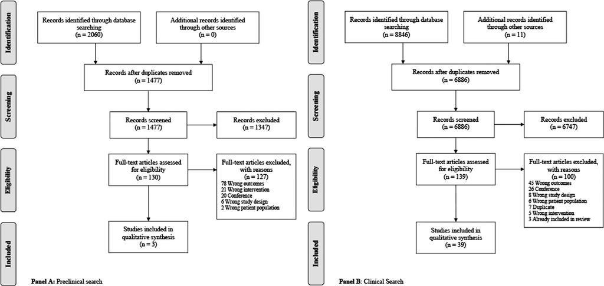

Fig. 1. PRISMA-ScR Flow Diagram.

3

Table 1

Dose dimensions and reported outcomes for included studies.

Reference

Author, Country, Sample size

Dose dimensionsa

Reported outcomes

Fixed vs. Manipulated

Time

Schedule

Intensity

Dose

Safety

Efﬁcacy

Preclinical: dose preparation

Bell 2015 [26]

USA, n = 27b

Fixed

15 min

5 d/w, 2 w

Aim 100 reps

Manipulated

0 vs 1 vs 2 s/d

Jeffers 2018 [27]

Canada, n = 27b

Fixed

15 min

3 s/d, 5 d/w, > 3 w

45-min rest

Manipulated

MacLellan 2011 [28]

Canada, n = 39c

Fixed

240 min

1 s/d, 5 d/w, 6w

Manipulated

Limited pellets vs unlimited pellets

Clinical: Phase I, dose ranging

Colucci 2017 [24]

UK, n = 15

Fixed

1 s/d, 5 d/w, 2 w

Manipulated

50 vs 100 vs 167 vs 251 vs 209 reps

Dite 2015 [23]

Australia, n = 6

Fixed

1 s/d, 3 d/w, 12 w

Manipulated

360 vs 630 vs 750 min

Clinical: Phase IIA, dose screening

Banina 2020 [29]

Canada, n = 41

Fixed

90 min

1 s/d, 5 d/w, 2 w

Manipulated

Birkenmeier 2010 [17]

USA, n = 15

Fixed

60 min

1 s/d, 3 d/w, 6 w

Aim > 300 reps

Manipulated

Carl 2016 [30]

USA, n = 18

Fixed

30 min

1 s/d, 1 d/w, 3 w

Manipulated

30- vs 60- vs 90-sec rest

Milot 2019 [31]

Canada, n = 12

Fixed

60 min

1 s/d, 3 d/w, 4w

BRPE 12-13/20 progress to 15-60/20

by 4 w.

Manipulated

Nordin 2019 [32]

Exercise, n = 41

Fixed

90 min

1 s/d, 1 d/w, 12 w

Manipulated

Norouzi-Gheidar 2019 [33]

Canada, n = 18

Fixed

1 s/d, 2–3 d/w, 4w

Aim 70% score on games

Manipulated

Usual care vs usual

care + 30 min

Schneider 2019 [34]

Upper limb, n = 20

Fixed

60 min

1 s/d, 6 d/w, 4w

Manipulated

Vinstrup 2018 [35]

Denmark, n = 18

Fixed

1s

3 reps/s

Manipulated

Easy vs moderate vs hard resistance

Waddell 2014 [36]

USA, n = 15

Fixed

60 min

1 s/d, 4 d/w, length of admission

Aim > 300 reps/s

Manipulated

Clinical: Phase IIB, dose ﬁnding (response)

Allison 2007[37]

UK, n = 17

Fixed

45 min

5 d/w, length of admission

Manipulated

1 s/d vs 2 s/d

USA, n = 35

Fixed

20 min

Length of admission

110/125% self-selected walking

speed. 75% of 1RM. 60–80% of max HR

Manipulated

Usual care vs usual care + 6 s/w

Burgar 2011[39]

USA, n = 54

Fixed

60 min

5 d/w, 3 w

Manipulated

1 s/d vs 2 s/d

de Sousa 2019[40]

Australia, n = 30

Fixed

120 vs 180–240 min

Manipulated

2 s/d, 5 d/w vs 4 s/d, 6 d/w

Dromerick 2009 [41]

USA, n = 52

Fixed

5 d/w, 2 w

Manipulated

120 vs 180 min

Elsner 2018 [42]

Germany, n = 20

Fixed

1s

Manipulated

1- vs 4-min rest

GAPS 2004 [43]

UK, n = 70

Fixed

1 s/d, 5 d/w, 4w

Manipulated

30–40 vs 60–80 min

Han 2012[44]

China, n = 32

Fixed

1 s/d, 5 d/w, 6 w

Manipulated

60 vs 120 vs 180 min

4

Table 1 (Continued )

Reference

Author, Country, Sample size

Dose dimensionsa

Reported outcomes

Fixed vs. Manipulated

Time

Schedule

Intensity

Dose

Safety

Efﬁcacy

Hornby 2019 [15]

USA, n = 97

Fixed

40 min

1 s/d, 35 d/w, 8w

Manipulated

30–40% vs 70–80% HRR

Hsieh 2011 [16]

Taiwan, n = 18

Fixed

90-105 min

1 s/d, 5 d/w, 4w

Manipulated

900 vs 1800 reps

Hsieh 2012 [45]

Taiwan, n = 54

Fixed

90-100 min

1 s/d, 5 d/w, 4w

Manipulated

375–500 vs 750–1000 reps

Hsu 2010 [46]

Taiwan, n = 66

Fixed

1 s/d, 5 d/w, 4w

Manipulated

0 vs 30 vs 60 min

Hsu 2012 [47]

Taiwan, n = 95

Fixed

1 s/d, 5 d/w, 4w

Manipulated

0 vs 15 vs 30 vs 60 min

Hunter 2011 [48]

UK, n = 76

Fixed

1 s/d, 5 d/w, 2 w

Manipulated

0 vs 30 vs 60 vs 120 min

Kowalczewski 2007 [49]

UK, n = 19

Fixed

1 s/d, 5 d/w, 34 w

Manipulated

15 vs 60 min

Lang 2016 [4]

Waddell 2017 [14]

USA, n = 85

Fixed

60 min

1 s/d, 4 d/w, 8 w

Manipulated

3200 vs 6400 vs 9600 vs > 9600 reps

Lincoln 1999 [50]

UK, n = 282

Fixed

1 s/d, 5 d/w, 5 w

Manipulated

30–45 vs 54–79 min

Page 2012 [51]

USA, n = 32

Fixed

1 s/d, 5 d/w, 8 w

Manipulated

30 vs 60 vs 120 min

Patel 2019[52]

USA, n = 13

Fixed

1 s/d, 5 d/w

200–300 reps

Manipulated

180 vs 240 min

Tong 2019[53]

China, n = 248

Fixed

7 d/w, 2 w

Manipulated

<90 vs 180 min

Winstein 2019 [54]

USA, n = 45

Fixed

1 s/d, 4 d/w, 15 w

Manipulated

0 vs 900 vs 1800 vs

3600 min

Wu, 2019 [55]

China, n = 32

Fixed

30–90 min

5 d/w, 2 w

Manipulated

1 s/d vs 3 s/d

Clinical: Phase IIB, dose ﬁnding (optimal)

Di Lauro 2003 [56]

Italy, n = 60

Fixed

12 s/d, 5 d/w, 2 w

Manipulated

45 vs 120 min

Doucet 2013 [57]

USA, n = 16

Fixed

20–40 min

1 s/d, 4 d/w, 4 w

Manipulated

20 Hz e-stim vs 40 Hz e-stim

Partridge 2000 [58]

UK, n = 114

Fixed

1 s/d, 5 d/w, 6 w

Manipulated

30 vs 60 min

Rodgers 2003 [59]

UK, n = 123

Fixed

1 s/d, 5 d/w, 6 w

Manipulated

Usual care vs usual

care + 30 min

Sivenius 1985 [60]

Finland, n = 95

Fixed

2 s/d

Manipulated

d: day/; d/w, day/week; HR, heart rate; HRR, heart rate reserve; Hz: Hertz; NR: not reported; 1RM: one repetition maximum; s: sessions; reps: repetitions; reps/s: repetitions/sessions; sec: seconds; s/d: sessions/day; s/w: sessions/

week; w: week; BRPE: Borg Rating of Perceived Exertion Scale.

a Dose dimensions deﬁned as ﬁxed, remain stable or consistent throughout study or manipulated, articulated or change within study.

b Results from experiment 1 only.

c Results from experiment 2 only.

* Safety outcomes related to stroke inducement reported but no safety outcomes reported for intervention.

5

that aimed to determine efﬁcacy. All preclinical experiments

reported dose and efﬁcacy; however, intervention safety outcomes

were not reported. Phase I trials aimed to determine the maximum

tolerated dose with rule-based designs; dose and safety outcomes

were consistently reported. The aim of Phase IIA trials focused on

safety and feasibility of high repetitions or intensity of dose. All

Phase IIA trials reported dose, but 2 did not report safety outcomes.

Phase IIB dose-ﬁnding (response) trials predominately aimed to

determine the effect of dose on motor outcomes, through a

randomized controlled trial. All dose–response trials reported

efﬁcacy; however, dose outcomes were reported in only half, and

fewer (41%) reported safety outcomes. Most Phase IIB dose ﬁnding

(optimal) trials aimed to compare the effect of different doses.

Efﬁcacy outcomes were reported by all dose optimization trials,

but dose outcomes were reported in only 40%, and no trials

reported safety outcomes. Thus, the frequency of dose and safety

outcome reporting decreased along the discovery pipeline.

Fig. 2 illustrates results at the trial phase level. The proportion

was lower for preclinical (7%), Phase I (5%), and Phase IIA (22%)

studies than Phase IIB studies (66%). The systematic translation of

ﬁndings along the discovery pipeline (i.e., one phase informing the

next) was poorly demonstrated. The justiﬁcation of dose for Phase I

trials included preclinical experiments but also later-phase clinical

trials. No included Phase IIA trials were based on dose outcomes of

a Phase I trial, and only one Phase IIB trial [4] tested dose outcomes

from a published Phase IIA trial[17].

The mean intervention description score was 61% (ARRIVE 68%,

TIDieR 61%; Fig. 2) despite 78% of studies being published after

2010. There were 5 ARRIVE questions (7/8/10/11/18) that all

preclinical experiments failed to sufﬁciently report, covering

experiment information and animals, sample size, and interpreta-

tion of results. No included clinical trials reported modiﬁcations to

the intervention (TIDieR Question 10), and only 40% reported

ﬁdelity (TIDieR Question 12). Intervention description results by

question are reported in Supplement File 2 (Appendix B). The

overall risk of bias scores (SYRCLE, ROBINS-I, Cochrane RoB2)

demonstrated that most studies were at high risk of bias (SYRCLE

n = 3/3, ROBINS-I n = 3/11, Cochrane RoB2 n = 19/27, Fig. 3).

discovery pipeline. Justiﬁcation for the dose regimen (19% EPRQC

Question 6B) and the starting dose (21% EPRQC Question 5B) were

the lowest reported across preclinical experiments and clinical

trials, followed by whether studies differentiate between causality

related and unrelated adverse events (37% EPRQC Question 3).

Quality results by question and phase are reported in Supplement

File 2 (Appendix B).

4. Discussion

This review found a disproportionally small number of early-

phase studies that investigated dose in comparison to the volume

of

published

behavioral

motor

stroke

recovery

research

[13,18].

Preclinical

experiments

and

Phase

I

clinical

trials

represented 12% of included studies, highlighting a gap early in

the discovery pipeline. All studies adopted a unidimensional dose

articulation approach (i.e., the investigation of a single dose

dimension), and most focused on upper-limb interventions as

compared with other domains (lower limb, exercise, function).

Preclinical experiments were all at high risk of bias but in

comparison to clinical trials, did marginally better at intervention

reporting and dose articulation. Outcome reporting of dose and

safety declined along the discovery pipeline, as did intervention

description, risk of bias, and quality scores.

Early phase stroke recovery research has adopted a unidimen-

sional approach to investigate dose of behavioral motor inter-

ventions. In this review, studies most commonly selected time as

the dimension to manipulate, with the outcome usually reported

as time in therapy environment. This provided limited information

regarding actual work performed [19]. The intervention domain

should guide the researcher to select multiple dose dimensions to

investigate, building a comprehensive dose outcome. For example,

time spent actively working and repetitions per minute could

provide a measure of time and intensity respectively for an upper-

limb trial. The idea that dose is multidimensional is not new in the

ﬁeld [9]; Lang et al. previously reported that ‘‘optimal dosing will

not likely be a single value’’ [7]. To successfully complete

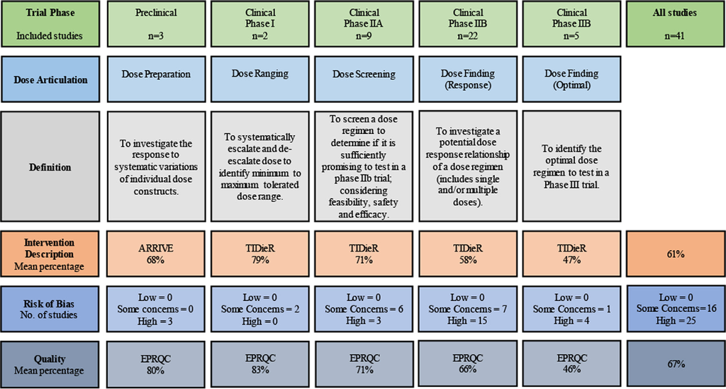

Fig. 2. Discovery pipeline including intervention description, risk of bias and quality outcomes.

6

multidimensional, early-phase dose articulation research, we need

to establish a consistent dose deﬁnition that operationalizes the

multiple dimensions that can be applied to preclinical and clinical

stroke recovery research.

The lack of dose articulation studies included in the review also

suggests

that

the

ﬁeld

has

overlooked

the

importance

of

conducting research along the discovery pipeline [6]. A systematic

phased approach is required to develop new pharmaceutical

interventions [1]. This approach provides regulatory bodies [1]

with key information (i.e., safe and tolerable dose range) to inform

the approval of new pharmaceutical interventions. Phase IIB trials

included in this review skipped trial phases in the discovery

pipeline, which meant dose (feasibility and tolerability) and safety

outcomes were inadequately explored. This ﬁnding was previously

discussed by Dobkin et al., [20] who reported that rehabilitation

trials have tended to ‘‘move forward in random increments

compared to the FDA process for drug approval’’. Skipping trial

phases can result in inadequate justiﬁcation of the dose selected

for inclusion in later-phase efﬁcacy trials (i.e., not based on a safe

and tolerable dose range). A recent review found that only 36 of

194 randomized controlled stroke recovery trials provided a

justiﬁcation (i.e., earlier phase study) for intervention dose

[21]. The adoption of a systematic discovery pipeline approach

should result in more early-phase studies (preclinical, Phase I and

Phase IIA) and fewer Phase III trials being completed. From this

process, the resulting Phase III trials will have been developed

based on a safe and tolerable dose, allowing conﬁdence that the

results truly reﬂect the intervention outcome.

Reporting of outcomes varied along the pipeline. Preclinical

experiments and clinical Phase I/IIA trials consistently reported dose

outcomes. There was a steep drop off at Phase IIB study, with less

than half reporting dose outcomes, despite a stated dose articulation

aim. The actual dose achieved can affect intervention efﬁcacy and

research replication. Safety outcomes also followed a similar pattern

of reporting along the pipeline. Reporting safety outcomes is critical

for all behavioral motor intervention trials because interventions

cannot be assumed safe [22]. Although the purpose of a Phase IIB

trial does shift to focus on efﬁcacy, this review demonstrated the

need for better reporting of dose and safety even at this phase to

ensure adequate justiﬁcation of dose in later-phase trials.

Phase I trials were poorly represented in the overall results,

with the 2 included trials [23,24] adopting a unidimensional

approach to dose articulation. This ﬁnding highlights a lack of

published Phase I, dose-ranging trials in the ﬁeld of behavioral

motor stroke recovery. A likely contributor to this research gap is a

poor understanding of how to conduct a multidimensional Phase I

trial. Classical Phase I trial designs have been developed in the

pharmaceutical ﬁeld to investigate the single dimension of

‘‘amount of drug’’ (usually measured in milligrams) [25]. To

successfully investigate the dose of behavioral motor interven-

tions, we need to understand the design attributes inherent in

Phase

I

trials

and

adapt

them

for

multidimensional

dose

articulation. Early-phase research, particularly the appropriate

design and implementation of multidimensional Phase I trials,

warrants further attention in behavioral motor stroke recovery.

There are some limitations to this review. The restriction of the

preclinical inclusion criteria to yield a manageable number of

search results could have resulted in missing some preclinical,

dose-preparation experiments of other domains (e.g., lower limb).

One person completed the ﬁrst review of title and abstracts;

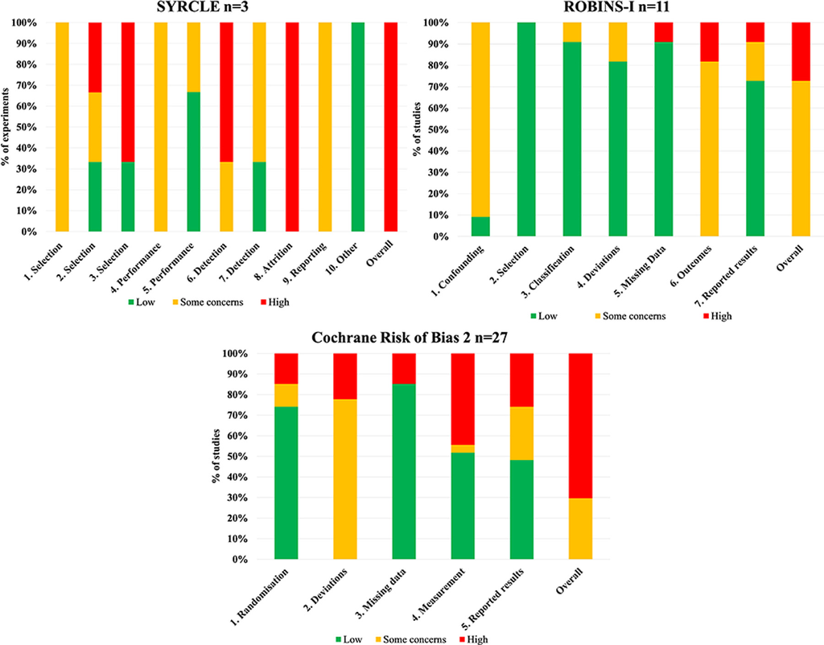

Fig. 3. Risk of bias.

7

however, a low threshold was used to move papers to full-text

review. Studies not published in English were also excluded. The

strengths are the search for both preclinical experiments and

clinical trials via the adoption a systematic discovery pipeline

approach to understand the continuum of trial phases. Use of the

EPRQC [6] also enabled rating the quality of included preclinical

and clinical studies with a consistent tool.

5. Conclusions

This review highlights that early-phase dose articulation

research of behavioral motor interventions for stroke recovery is

in its infancy. There is a unique opportunity to adopt systematic

processes and collaborate across the discovery pipeline (preclinical

and clinical) to increase the volume of dose articulation research.

Researchers in the ﬁeld must consider how to adapt existing early-

phase trial designs, with a particular focus on Phase I, to

accommodate investigation of the multiple dimensions of dose.

Funding

This work was supported by an Australian Government Research

Training Program Scholarship; National Health and Medical Research

Council [KH:1088449; BC:1174514] and Heart Foundation Future Leader

Fellowship [NL:GNT102055].

Contributions

ED and KH conceived the idea for this review and were involved

in all aspects of study, with manuscript writing led by ED. LC and DC

were involved in the study design, study selection, rating of studies,

and manuscript editing. NL was involved in the study design, and

manuscript editing. BC was involved in manuscript editing. All

authors made signiﬁcant intellectual contributions to the review.

Disclosure of interest

The authors declare that they have no competing interest.

Acknowledgments

The Florey Institute of Neuroscience and Mental Health

acknowledges the support of the Victorian Government’s Opera-

tional Infrastructure Support Grant.

Appendix A. Supplementary data

Supplementary data associated with this article can be found, in

the online version, at https://doi.org/10.1016/j.rehab.2020.101469.

References

[1] U.S. Food and Drug Administration. Step 3: Clinical Research; 2018 [Accessed

2019. https://www.fda.gov/patients/drug-development-process/step-3-

clinical-research#Clinical_Research_Phase_Studies].

[2] Walker MF, Hoffmann TC, Brady MC, Dean CM, Eng JJ, Farrin AJ, et al. Improving

the development, monitoring and reporting of stroke rehabilitation research:

Consensus-based core recommendations from the Stroke Recovery and Reha-

bilitation Roundtable. Int J Stroke 2017;12:472–9. http://dx.doi.org/10.1177/

1747493017711815.

[3] Bernhardt J, Hayward K, Dancause N, Lannin N, Ward N, Nudo R, et al. A stroke

recovery trial development framework: Consensus-based core recommenda-

tions from the Second Stroke Recovery and Rehabilitation Roundtable. Int J

Stroke 2019;14:792–802. http://dx.doi.org/10.1177/1747493019879657.

[4] Lang CE, Strube MJ, Bland MD, Waddell KJ, Cherry-Allen KM, Nudo RJ, et al.

Dose response of task-speciﬁc upper limb training in people at least 6 months

poststroke: A phase II, single-blind, randomized, controlled trial. Ann Neurol

2016;80:342–54. http://dx.doi.org/10.1002/ana.24734.

[5] Craig P, Dieppe P, Macintyre S, Michie S, Nazareth I, Petticrew M. Developing

and evaluating complex interventions: the new Medical Research Council

guidance. BMJ 2008;337:a1655. http://dx.doi.org/10.1136/bmj.a1655.

[6] Dalton E, Churilov L, Lannin NA, Corbett D, Hayward K. Dose Articulation in

Preclinical and Clinical Stroke Recovery: Reﬁning a Discovery Research Pipe-

line and Presenting a Scoping Review Protocol. Front Neurol 2019;10:1148.

http://dx.doi.org/10.3389/fneur.2019.01148.

[7] Lang CE, Lohse KR, Birkenmeier RL. Dose and timing in neurorehabilitation.

Curr

Opin

Neurol

2015;28:549–55.

http://dx.doi.org/10.1097/

wco.0000000000000256.

[8] Lohse KR, Pathania A, Wegman R, Boyd LA, Lang CE. On the Reporting of

Experimental and Control Therapies in Stroke Rehabilitation Trials: A System-

atic Review. Arch Phys Med Rehabil 2018;99:1424–32. http://dx.doi.org/

10.1016/j.apmr.2017.12.024.

[9] Pollock A, Farmer SE, Brady MC, Langhorne P, Mead GE, Mehrholz J, et al.

Interventions for improving upper limb function after stroke. Cochrane

Database

Syst

Rev

2014;11:CD010820.

http://dx.doi.org/10.1002/

14651858.cd010820.pub2.

[10] Arksey H, O’Malley L. Scoping studies: towards a methodological framework.

Int

J

Soc

Res

Methodol

2005;8:19–32.

http://dx.doi.org/10.1080/

1364557032000119616.

[11] Levac D, Colquhoun H, O’Brien KK. Scoping studies: advancing the methodol-

ogy. Implementation Sci 2010;5:69. http://dx.doi.org/10.1186/1748-5908-5-

69.

[12] Tricco AC, Lillie E, Zarin W, O’Brien KK, Colquhoun H, Levac D, et al. PRISMA

Extension for Scoping Reviews (PRISMA-ScR): Checklist and Explanation. Ann

Intern Med 2018. http://dx.doi.org/10.7326/m18-0850.

[13] Bernhardt J, Hayward KS, Kwakkel G, Ward NS, Wolf SL, Borschmann K, et al.

Agreed deﬁnitions and a shared vision for new standards in stroke recovery

research: The Stroke Recovery and Rehabilitation Roundtable taskforce. Int J

Stroke 2017;12:444–50. http://dx.doi.org/10.1177/1747493017711816.

[14] Waddell KJ, Strube MJ, Bailey RR, Klaesner JW, Birkenmeier RL, Dromerick AW,

et al. Does Task-Speciﬁc Training Improve Upper Limb Performance in Daily

Life Poststroke? Neurorehabili Neural Repair 2017;31:290–300. http://

dx.doi.org/10.1177/1545968316680493.

[15] Hornby T, Henderson C, Plawecki A, Lucas E, Lotter J, Holthus M, et al.

Contributions of Stepping Intensity and Variability to Mobility in Individuals

Poststroke.

Stroke

2019;50:2492–9.

http://dx.doi.org/10.1161/stro-

keaha.119.026254.

[16] Hsieh Y, Wu C, Liao W, Lin K, Wu K, Lee C. Effects of treatment intensity in

upper limb robot-assisted therapy for chronic stroke: a pilot randomized

controlled

trial.

Neurorehabil

Neural

Repair

2011;25:503–11.

http://

dx.doi.org/10.1177/1545968310394871.

[17] Birkenmeier RL, Prager EM, Lang CE. Translating Animal Doses of Task-Speciﬁc

Training to People With Chronic Stroke in 1-Hour Therapy Sessions: A Proof-

of-Concept Study. Neurorehabil Neural Repair 2010;24:620–35. http://

dx.doi.org/10.1177/1545968310361957.

[18] Mayo NE, Kaur N, Barbic SP, Fiore J, Barclay R, Finch L, et al. How have research

questions and methods used in clinical trials published in Clinical Rehabilita-

tion changed over the last 30 years? Clin Rehabil 2016;30:847–64. http://

dx.doi.org/10.1177/0269215516658939.

[19] Lohse KR, Lang CE, Boyd LA. Is More Better? Using Metadata to Explore Dose–

Response Relationships in Stroke Rehabilitation.

Stroke 2014;45:2053–8.

http://dx.doi.org/10.1161/strokeaha.114.004695.

[20] Dobkin BH. Progressive Staging of Pilot Studies to Improve Phase III Trials for

Motor Interventions. Neurorehabil Neural Repair 2009;23:197–206. http://

dx.doi.org/10.1177/1545968309331863.

[21] Borschmann K, Hayward KS, Raffelt A, Churilov L, Kramer S, Bernhardt J.

Rationale for Intervention and Dose Is Lacking in Stroke Recovery Trials: A

Systematic Review. Stroke Res Treatment 2018;2018:1–9. http://dx.doi.org/

10.1155/2018/8087372.

[22] Avert Trial Collaboration Group, Bernhardt J, Langhorne P, Lindley RI, Thrift AG,

Ellery F, et al. Efﬁcacy and safety of very early mobilisation within 24 h of

stroke onset (AVERT): a randomised controlled trial. Lancet 2015;386:46–55.

[23] Dite W, Langford ZN, Cumming TB, Churilov L, Blennerhassett JM, Bernhardt J.

A Phase 1 exercise dose escalation study for stroke survivors with impaired

walking. Int J Stroke 2015;10:1051–6. http://dx.doi.org/10.1111/ijs.12548.

[24] Colucci E, Clark A, Lang CE, Pomeroy VM. A rule-based, dose-ﬁnding design for

[25] Tourneau CL, Lee JJ, Siu LL. Dose Escalation Methods in Phase I Cancer Clinical

Trials. J Natl Cancer Inst 2009;101:708–20. http://dx.doi.org/10.1093/jnci/

djp079.

[26] Bell JA, Wolke ML, Ortez RC, Jones TA, Kerr AL. Training Intensity Affects Motor

Rehabilitation Efﬁcacy Following Unilateral Ischemic Insult of the Sensorimo-

tor Cortex in C57BL/6 Mice. Neurorehabil Neural Repair 2015;29:590–8.

http://dx.doi.org/10.1177/1545968314553031.

[27] Jeffers MS, Karthikeyan S, Gomez-Smith M, Gasinzigwa S, Achenbach J, Feiten

A, et al. Does Stroke Rehabilitation Really Matter Part B: An Algorithm for

Prescribing an Effective Intensity of Rehabilitation. Neurorehabil Neural Re-

pair 2018;32:73–83. http://dx.doi.org/10.1177/1545968317753074.

[28] MacLellan CL, Keough MB, Granter-Button S, Chernenko GA, Butt S, Corbett D.

A Critical Threshold of Rehabilitation Involving Brain-Derived Neurotrophic

Factor Is Required for Poststroke Recovery. Neurorehabil Neural Repair

2011;25:740–8. http://dx.doi.org/10.1177/1545968311407517.

[29] Banin˜a MC, Molad R, Solomon JS, Berman S, Soroker N, Frenkel-Toledo S, et al.

Exercise intensity of the upper limb can be enhanced using a virtual rehabili-

tation system. Disabil Rehabilit Assistive Technol 2020;15:1–7. http://

dx.doi.org/10.1080/17483107.2020.1765421.

8

[30] Carl DL, Boyne P, Rockwell B, Gerson M, Khoury J, Kissela B, et al. Preliminary

safety analysis of high-intensity interval training (HIIT) in persons with

chronic stroke. Appl Physiol Nutr Metab 2017;42:311–8. http://dx.doi.org/

10.1139/apnm-2016-0369.

[31] Milot M-H, Le´onard G, Corriveau H, Desrosiers J. Using the Borg rating of

perceived exertion scale to grade the intensity of a functional training program

of the affected upper limb after a stroke: a feasibility study. Clin Interv Aging

2019;14:9–16. http://dx.doi.org/10.2147/cia.s179691.

[32] Nordin NAM, Yusoff NAH, Singh DKA. Facilitating Exercise Engagement among

Community Dwelling Stroke Survivors: Is a once Per Week Group Session

Sufﬁcient? Int J Environment Res Public Health 2019;16:4746. http://

dx.doi.org/10.3390/ijerph16234746.

[33] Norouzi-Gheidari N, Hernandez A, Archambault PS, Higgins J, Poissant L, Kairy

D. Feasibility, Safety and Efﬁcacy of a Virtual Reality Exergame System to

Supplement Upper Extremity Rehabilitation Post-Stroke: A Pilot Randomized

Clinical Trial and Proof of Principle. Int J Environment Res Public Health

2019;17:113. http://dx.doi.org/10.3390/ijerph17010113.

[34] Schneider EJ, Ada L, Lannin NA. Extra upper limb practice after stroke: a

feasibility study. Pilot Feasibil Stud 2019;5:156. http://dx.doi.org/10.1186/

s40814-019-0531-5.

[35] Vinstrup J, Calatayud J, Jakobsen M, Sundstrup E, Jørgensen J, Casan˜a J, et al.

Hand strengthening exercises in chronic stroke patients: Dose-response eval-

uation using electromyography. J Hand Ther 2017;31:111–21. http://

dx.doi.org/10.1016/j.jht.2017.01.004.

[36] Waddell KJ, Birkenmeier RL, Moore JL, Hornby TG, Lang CE. Feasibility of High-

Repetition. Task-Speciﬁc Training for Individuals With Upper-Extremity Pa-

resis

Am

J

Occup

Ther

2014;68:444.

http://dx.doi.org/10.5014/

ajot.2014.011619.

[37] Allison R, Dennett R. Pilot randomized controlled trial to assess the impact of

additional supported standing practice on functional ability post stroke. Clin

Rehabil 2007;21:614–9. http://dx.doi.org/10.1177/0269215507077364.

[38] Bowden MG, Monsch ED, Middleton JA, Daughtry C, Powell T, Kraft SV, et al.

The Difﬁculties of Incorporating Intensity Principles into Inpatient Stroke

Rehabilitation.

Arch

Rehabil

Res

Clin

Transl

2020;2:100052.

http://

dx.doi.org/10.1016/j.arrct.2020.100052.

[39] Charles GB, Peter SL, Scremin AME, Susan LG, Loos HFMVd, Deborah K, et al.

Robot-assisted upper-limb therapy in acute rehabilitation setting following

[40] Sousa DGd, Harvey LA, Dorsch S, Varettas B, Jamieson S, Murphy A, et al. Two

weeks of intensive sit-to-stand training in addition to usual care improves sit-

to-stand ability in people who are unable to stand up independently after

stroke: a randomised trial. J Physiother 2019;65:152–8. http://dx.doi.org/

10.1016/j.jphys.2019.05.007.

[41] Dromerick AW, Lang CE, Birkenmeier RL, Wagner JM, Miller JP, Videen TO, et al.

Very Early Constraint-Induced Movement during Stroke Rehabilitation (VEC-

TORS).

Neurology

2009;73:195–201.

http://dx.doi.org/10.1212/

wnl.0b013e3181ab2b27.

[42] Elsner B, Schweder S, Mehrholz J. Immediate effects of rest periods on balance

control in patients after stroke. A randomized controlled pilot trial. BMC Res

Notes 2018;11:338. http://dx.doi.org/10.1186/s13104-018-3450-2.

[43] The Glasgow Augmented Physiotherapy Study g. Can augmented physiother-

apy input enhance recovery of mobility after stroke? A randomized controlled

trial.

Clin

Rehabil

2004;18:529–37.

http://dx.doi.org/10.1191/

0269215504cr768oa.

[44] Han Q, Wang Q, Meng P, Qi M. Effects of intensity of arm training on

hemiplegic upper extremity motor recovery in stroke patients: a randomized

controlled trial. Clin Rehabil 2012;27:75–81. http://dx.doi.org/10.1177/

0269215512447223.

[45] Hsieh Y, Wu C, Lin K, Yao G, Wu K, Chang Y. Dose–Response Relationship of

Robot-Assisted Stroke Motor Rehabilitation. Stroke 2012;43:2729–34. http://

dx.doi.org/10.1161/strokeaha.112.658807.

[46] Hsu S, Hu M, Wang Y, Yip P, Chiu J, Hsieh C. Dose-Response Relation Between

Neuromuscular Electrical Stimulation and Upper-Extremity Function in

Patients With Stroke. Stroke 2010;41:821–4. http://dx.doi.org/10.1161/stro-

keaha.109.574160.

[47] Hsu S, Hu M, Luh J, Wang Y, Yip P, Hsieh C. Dosage of neuromuscular electrical

stimulation: Is it a determinant of upper limb functional improvement in

stroke patients? J Rehabil Med 2012;44:125–30. http://dx.doi.org/10.2340/

16501977-0917.

[48] Hunter S, Hammett L, Ball S, Smith N, Anderson C, Clark A, et al. Dose–Response

Study of Mobilisation and Tactile Stimulation Therapy for the Upper Extremity

Early After Stroke. Neurorehabil Neural Repair 2011;25:314–22. http://

dx.doi.org/10.1177/1545968310390223.

[49] Kowalczewski J, Gritsenko V, Ashworth N, Ellaway P, Prochazka A. Upper-

Extremity Functional Electric Stimulation–Assisted Exercises on a Worksta-

tion in the Subacute Phase of Stroke Recovery. Arch Phys Med Rehabil

2007;88:833–9. http://dx.doi.org/10.1016/j.apmr.2007.03.036.

[50] Lincoln N, Parry R, Vass C. Randomized, Controlled Trial to Evaluate Increased

Intensity of Physiotherapy Treatment of Arm Function After Stroke. Stroke

1999;30:573–9. http://dx.doi.org/10.1161/01.str.30.3.573.

[51] Page SJ, Levin L, Hermann V, Dunning K, Levine P. Longer Versus Shorter Daily

Durations of Electrical Stimulation During Task-Speciﬁc Practice in Moder-

ately Impaired Stroke. Arch Phys Med Rehabil 2012;93:200–6. http://

dx.doi.org/10.1016/j.apmr.2011.09.016.

[52] Patel J, Fluet G, Qiu Q, Yarossi M, Merians A, Tunik E, et al. Intensive virtual

reality and robotic based upper limb training compared to usual care, and

associated cortical reorganization, in the acute and early sub-acute periods

post-stroke: a feasibility study. J Neuroeng Rehabil 2019;16:92. http://

dx.doi.org/10.1186/s12984-019-0563-3.

[53] Tong Y, Cheng Z, Rajah G, Duan H, Cai L, Zhang N, et al. High Intensity Physical

Rehabilitation Later Than 24 h Post Stroke Is Beneﬁcial in Patients: A Pilot

Randomized Controlled Trial (RCT) Study in Mild to Moderate Ischemic Stroke.

Front Neurol 2019;10:113. http://dx.doi.org/10.3389/fneur.2019.00113.

[54] Winstein C, Kim B, Kim S, Martinez C, Schweighofer N. Dosage Matters. Stroke

2019. http://dx.doi.org/10.1161/strokeaha.118.023603.

[55] Wu W-X, Zhou C-Y, Wang Z-W, Chen G-Q, Chen X-L, Jin H-M, et al. Effect of Early

and Intensive Rehabilitation after Ischemic Stroke on Functional Recovery of the

Lower Limbs: A Pilot, Randomized Trial. J Stroke Cerebrovasc Dis 2020;29:

104649. http://dx.doi.org/10.1016/j.jstrokecerebrovasdis.2020.104649.

[56] Di Lauro A, Pellegrino L, Savastano G, Ferraro C, Fusco M, Balzarano F, et al. A

randomized trial on the efﬁcacy of intensive rehabilitation in the acute phase

of ischemic stroke. J Neurol 2003;250:1206–8. http://dx.doi.org/10.1007/

s00415-003-0185-2.

[57] Doucet B, Grifﬁn L. High-versus low-frequency stimulation effects on ﬁne

motor control in chronic hemiplegia: a pilot study. Top Stroke Rehabil

2013;20:299–307. http://dx.doi.org/10.1310/tsr2004-299.

[58] Partridge C, Mackenzie M, Edwards S, Reid A, Jayawardena S, Guck N, et al. Is

dosage of physiotherapy a critical factor in deciding patterns of recovery from

stroke:

a

pragmatic

randomized

controlled

trial.

Physiother

Res

Int

2000;5:230–40. http://dx.doi.org/10.1002/pri.203.

[59] Rodgers H, Mackintosh J, Price C, Wood R, McNamee P, Fearon T, et al. Does an

early increased-intensity interdisciplinary upper limb therapy programme

following acute stroke improve outcome? Clin Rehabil 2003;17:579–89.

http://dx.doi.org/10.1191/0269215503cr652oa.

[60] Sivenius J, Pyo¨ra¨la¨ K, Heinonen O, Salonen JT, Riekkinen P. The signiﬁcance of

intensity of rehabilitation of stroke–a controlled trial. Stroke 1985;16:928–31.

http://dx.doi.org/10.1161/01.str.16.6.928.

9